# Abces dentaires - Rouen

2023-02-05

# Descriptive analysis

We have 467 **unique patients** and 475 **unique hospital stays/emergency ward visits** so basically every patient consulted only once for dental problems, at the hospital, over the period of interest which is the calendar year 2021.

## Age & gender

**Mean age** for both sex combined is 37.16 years (*sd* = 15.61) while it’s 38.92 (*sd* = 17.21) for women and 35.99 (*sd* = 14.34) for men.

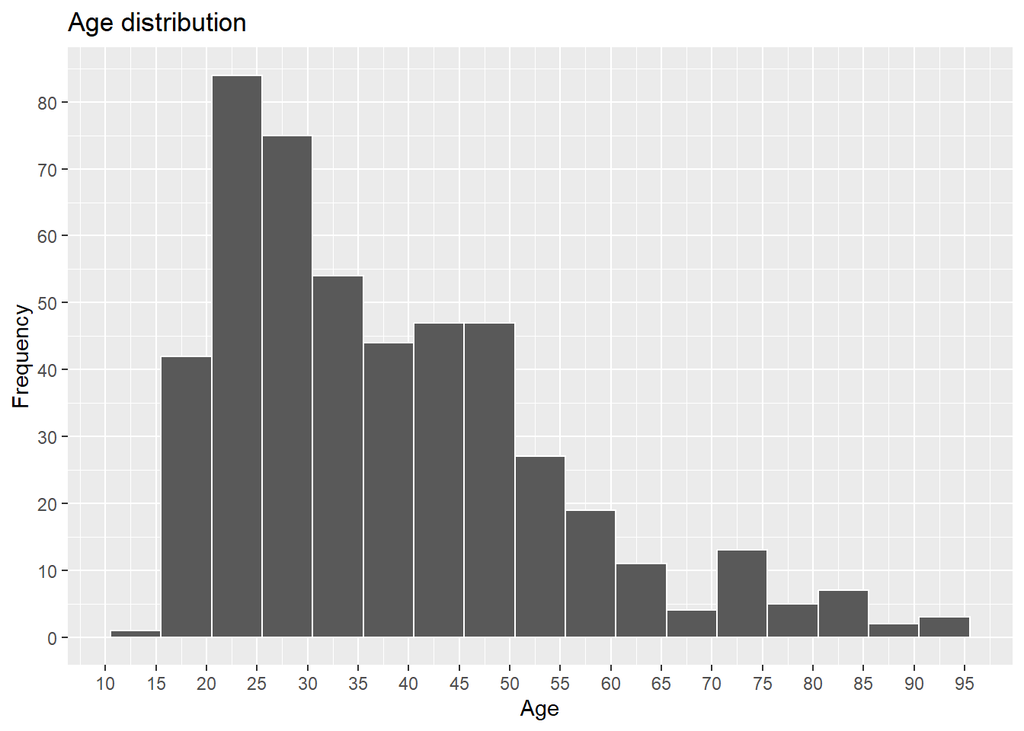

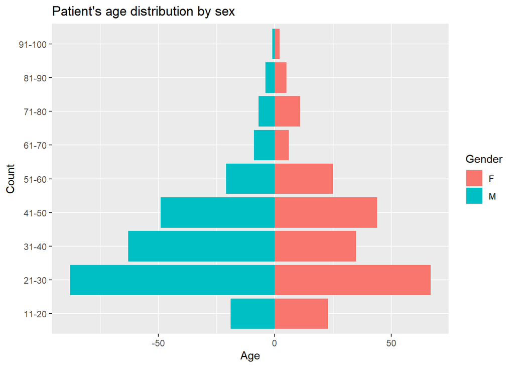

[figure not shown]

## Consultations

100% of the consultations/stays started with a visit to the emergency ward, coming from domicile as it was a selection criteria.

Patient consulted for:

| Main diagnosis | n | Freq |
| --- | --- | --- |
| Abces periapical | 344 | 72.42% |
| Autres affections precisees des dents et du parodonte | 73 | 15.37% |
| Carie | 21 | 4.42% |
| Abces periapical avec fistule | 14 | 2.95% |
| Maladies de la pulpe et des tissu périapicaux, autres et sans précision | 7 | 1.47% |
| Periodontite aigue | 7 | 1.47% |
| Maladie périodontale, sans précision | 4 | 0.84% |
| Affection de la gencive et de la crête alvéolaire édentée, sans précision | 2 | 0.42% |
| Affection des dents et du parodonte, sans precision | 2 | 0.42% |
| Periodondite | 1 | 0.21% |

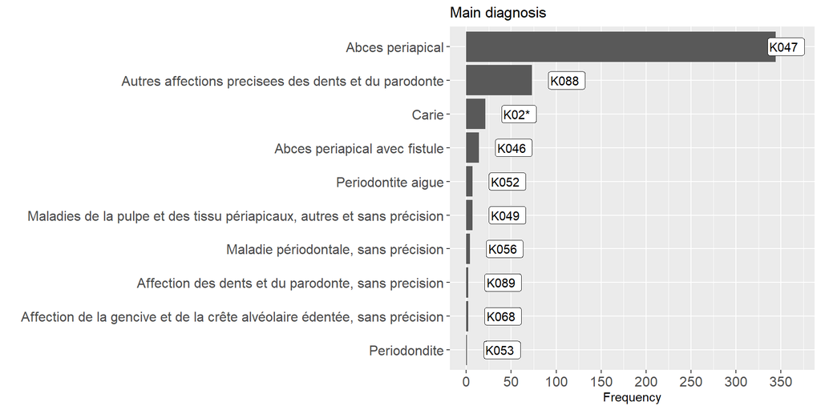

## Stays

**Entered wards**

| Ward | Visits nb | Overall time spent | Mean time spent | Visits % | Time spent % |
| --- | --- | --- | --- | --- | --- |
| STOM | 153 | 735.63 | 4.81 | 17.27 | 43.56 |
| ORLO | 70 | 304.73 | 4.35 | 7.90 | 18.05 |
| URGE | 597 | 304.52 | 0.51 | 67.38 | 18.03 |
| REAC | 10 | 138.07 | 13.81 | 1.13 | 8.18 |
| OPHT | 17 | 52.10 | 3.06 | 1.92 | 3.09 |
| INTB | 6 | 32.18 | 5.36 | 0.68 | 1.91 |
| NEUC | 8 | 24.39 | 3.05 | 0.90 | 1.44 |
| GERI | 2 | 21.91 | 10.95 | 0.23 | 1.30 |
| ORTH | 4 | 14.43 | 3.61 | 0.45 | 0.85 |
| MINT | 2 | 11.06 | 5.53 | 0.23 | 0.65 |
| OBST | 1 | 9.63 | 9.63 | 0.11 | 0.57 |
| PEDE | 2 | 7.50 | 3.75 | 0.23 | 0.44 |
| UHAV | 3 | 7.19 | 2.40 | 0.34 | 0.43 |
| CGCD | 2 | 6.82 | 3.41 | 0.23 | 0.40 |
| CARD | 1 | 4.75 | 4.75 | 0.11 | 0.28 |
| CTHX | 2 | 4.62 | 2.31 | 0.23 | 0.27 |
| PNM1 | 1 | 4.07 | 4.07 | 0.11 | 0.24 |
| UROL | 2 | 3.37 | 1.69 | 0.23 | 0.20 |
| NEUX | 1 | 0.98 | 0.98 | 0.11 | 0.06 |
| REAM | 1 | 0.67 | 0.67 | 0.11 | 0.04 |
| URGP | 1 | 0.04 | 0.04 | 0.11 | 0.00 |

## Prescriptions

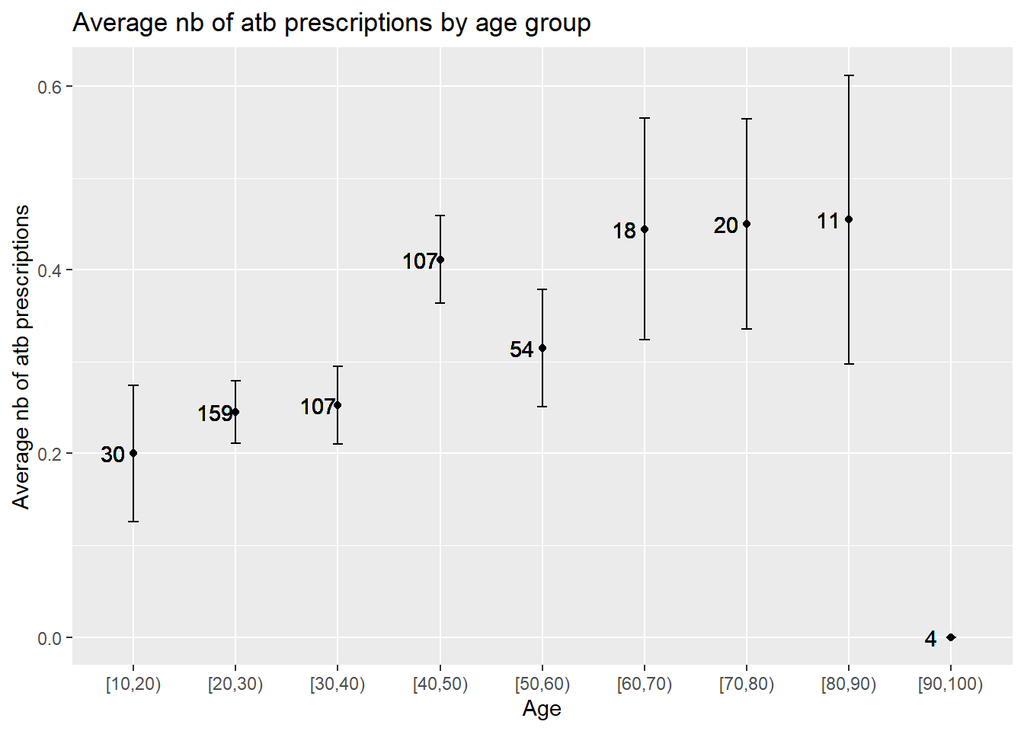

**Prescribed molecules**

| Antibiotic Administration site | Antibiotic Molecule | Antibiotic Dose | Antibiotic n | Antibiotic % | Prescription length Mean duration (days) | Prescription length Mode |
| --- | --- | --- | --- | --- | --- | --- |
| **IV** |  |  |  |  |  |  |
| iv | Augmentin | 1g/125mg | 21 | 91.3% | 3.39 | 2 |
| iv | Cefepime | 2000mg | 1 | 4.35% | 21.00 | 21 |
| iv | Metronidazole | 500mg | 1 | 4.35% | 21.00 | 21 |
| **OS** |  |  |  |  |  |  |
| os | Augmentin | 1g/125mg | 103 | 75.18% | 7.11 | 7 |
| os | Amoxicilline | 1g | 7 | 5.11% | 7.00 | 7 |
| os | Clindamycine | 600mg | 5 | 3.65% | 7.20 | 7 |
| os | Metronidazole | 500mg | 4 | 2.92% | 7.25 | 7 |
| os | Metronidazole/spiramycine | 250mg/1,5mg | 3 | 2.19% | 4.67 | 7 |
| os | Metronidazole/spiramycine | 250mg/1,5mg | 3 | 2.19% | 4.67 | 2 |
| os | Metronidazole/spiramycine | 250mg/1,5mg | 3 | 2.19% | 4.67 | 5 |
| os | Clindamycine/metronidazole | 600mg/500mg | 2 | 1.46% | 7.00 | 7 |
| os | Pristinamycine | 500mg | 2 | 1.46% | 9.00 | 10 |
| os | Pristinamycine | 500mg | 2 | 1.46% | 9.00 | 8 |
| os | Augmentin/metronidazole | 1g/125mg + 600mg | 1 | 0.73% | 7.00 | 7 |
| os | Azithromycine | 600mg | 1 | 0.73% | 5.00 | 5 |
| os | Tazocilline | 2g/250mg | 1 | 0.73% | 7.00 | 7 |

| Acte label | n | Unique patients | Rx on average |
| --- | --- | --- | --- |
| Radiographie panoramique dentomaxillaire | 179 | 38 | 4.71 |
| Radiographie volumique par faisceau conique [cone beam computerized tomography, CBCT] du maxillaire, de la mandibule et/ou d’arcade dentaire | 8 | 2 | 4.00 |
| Radiographie du crane et/ou du massif facial selon 1 ou 2 incidences | 4 | 2 | 2.00 |

# Regression logistique

|  | 2.5 % | 97.5 % | OR | p-value |
| --- | --- | --- | --- | --- |
| Patient - Male | 0.89 | 1.05 | 0.97 | 0.45 |
| Patient - age 21-60 | 0.97 | 1.3 | 1.12 | 0.12 |
| Patient - age 61-100 | 1.03 | 1.51 | 1.25 | 0.023 |
| CIM10 - Miscellanea | 0.78 | 1.18 | 0.96 | 0.70 |
| CIM10 - Carie | 0.79 | 1.18 | 0.97 | 0.74 |

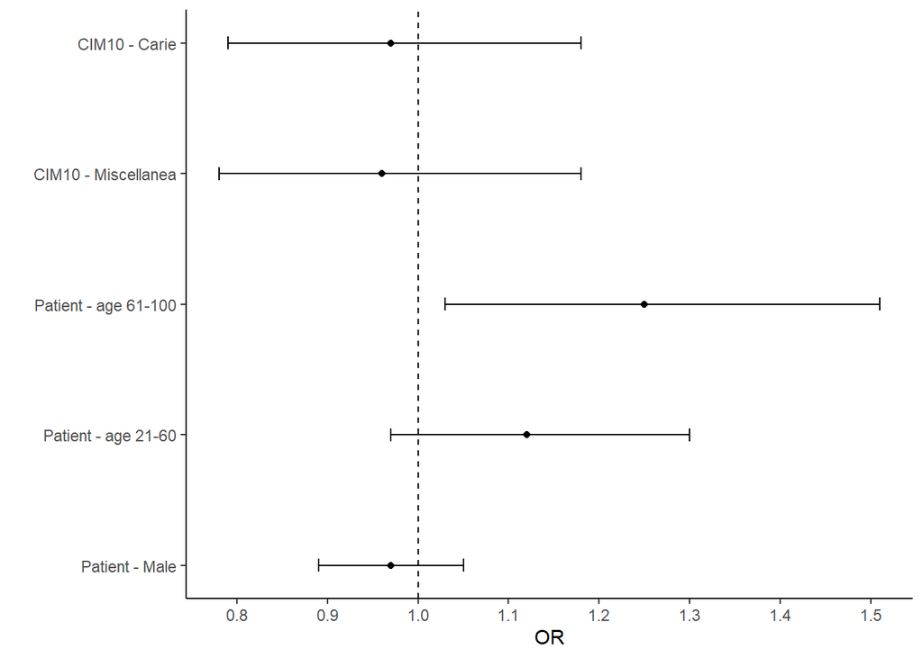

Patients 60+ yo are 25% more likely to receive an antibiotics prescription.